# Building figures from CSV files

```r
library(ggcpb)
```

# 1 Introduction

Figures can be created directly with or without using R. This vignette described the method to create figures **using only Excel**.

To create a figure, you need:

- a `params.csv` file
  - this is the parameter file, which specifies which figures to create and how they should be configured
  - one `params.csv` can contain the parameters for several figures
- a `data` folder with the dataset(s)
  - each dataset is a CSV file
- the `generate_plot.bat` script

*Please note*: The datasets must be saved as CSV, not as spreadsheet (`xlsx`). In Excel, choose `File` -> `Save as` -> `CSV UTF-8 (comma delimited)`.

## 1.1 How to create a figure without opening R?

The general workflow to create figures with ggcpb is as follows:

1. Find the folder `examples` in the installed ggcpb package. In R, `system.file("examples", package = "ggcpb")` returns the path to this folder.
2. Copy it to the place where you want to create figures.
3. Put your datasets in the folder `data`. Open `params.csv` in Excel and add your parameters.
4. To create a figure, double clik on `generate_plot.bat`. This reads `params.csv`, builds every figure and saves the images in the folder `generated`. Each image is named after its dataset. Running the script again produces updated figures. Images with the same name are replaced. A dataset or figure that fails is skipped and listed at the end, and in `params_log.txt`. The other figures are still saved.

*Please note*. The `generate_plot.bat`, `generate_plot.R` and `params.csv` must all be in the same folder. Within this folder, there must be a subfolder `data`, in which each dataset must be saved as a CSV file.

# 2 The dataset

Each dataset is a CSV file in the `data` folder. It can have any name. The first row holds the column names. The package example has two datasets. One of the example datasets is shown here:

| jaar | groep | koopkracht | werkloosheid |
| --- | --- | --- | --- |
| 2021 | werkenden | 0.3 | 3.4 |
| 2021 | gepensioneerden | -0.2 | 3.4 |
| 2021 | uitkering | -0.9 | 3.4 |
| 2022 | werkenden | -2.7 | 3.5 |
| 2022 | gepensioneerden | -2.3 | 3.5 |
| 2022 | uitkering | -3.2 | 3.5 |
| 2023 | werkenden | 1.5 | 3.6 |
| 2023 | gepensioneerden | 0.8 | 3.6 |
| 2023 | uitkering | -0.3 | 3.6 |
| 2024 | werkenden | 1.2 | 3.7 |
| 2024 | gepensioneerden | 0.6 | 3.7 |
| 2024 | uitkering | -0.5 | 3.7 |
| 2025 | werkenden | 0.9 | 3.7 |
| 2025 | gepensioneerden | 0.4 | 3.7 |
| 2025 | uitkering | -0.6 | 3.7 |

The parameter file refers to variables by their column names. Categorical columns (e.g. `regio`, `geslacht`) keep the order of the rows in the created figure. So, the first group in the CSV-file (e.g. here `werkenden`) is the first on the axis and in the legend.

# 3 The parameter file

The parameter file determines which figures are created. Each figure has a `plot_type`, together with the settings required for that plot type. The parameter `data` names the dataset of the figure.

The first column holds the parameter names. Every other column describes one figure. This is the example parameter file. The first row, with the plot types, is the header.

| plot_type | col | line |
| --- | --- | --- |
| data | koopkracht | werkloosheid |
| title | Koopkrachtontwikkeling naar groep | Werkloosheid |
| x | jaar | jaar |
| y | koopkracht | werkloosheid |
| ylab | % mutatie | % |
| fill | groep |  |
| sec_y | werkloosheid |  |
| sec_legend_label | werkloosheid |  |
| sec_ylab | % |  |
| style |  | english |
| sec_type | line |  |
| create | y | y |

This table shows that there are two figures. The first figure (see figure 1) is a column chart (`plot_type` = `col`) that uses the `koopkracht` dataset (`data`) and that portrays `werkloosheid` on the second y-axis (`sec_y`). The second figure (see figure 2) is a line chart (`plot_type` = `line`) that uses the `werkloosheid` dataset (`data`) and has no secondary y-axis. A parameter value can be left blank, such as `sec_y` in the second plot. Only the second figure sets `style` to `english`, so it gets English labels and number formats.

The parameter `page` sets the page width a figure is saved at: `half` (7.5 cm, the default), `full` (15.5 cm) or `small`. If left out, the default `half` is used.

## 3.1 Plot types

`plot_type` names the figure type: `line`, `col`, `area`, `box`, `boxplot_extended`, `dot`, `scatter`, `hist`, `donut` or `map`. Each type is in R the `cpb_` function of the same name, such as `cpb_line()`. Every argument of that function can be a parameter. Appendix A lists them all per plot type.

## 3.2 Special values

Most values are plain text, a number, `TRUE` or `FALSE`. A few need a special form:

| Value | Example | What happens |
| --- | --- | --- |
| a list | `0;100` | `;` separates the values. |
| a line break | `First sentence\nsecond sentence` | `\n` starts a new line. |
| no upper limit | `0;20;Inf` | `Inf` and `-Inf` are numbers. |
| a formatter | `euro` | `x_labels` and `sec_axis_labels` take `number` (1.000), `euro` (€1.000) or `pct` (1%). Own labels such as `a;b;c` work too. |
| pairs | `p5:onderste 5%` | `dot_labels` takes name:value pairs. |
| a date | `2024-01-31` | A dataset column of dates gives a date axis. `31-1-2024` works too. |

## 3.3 Classes

The parameter `cut_labels` says how the class limits are written:

- `number` (default) writes plain numbers, such as “20”.
- `euro` adds a euro sign, such as “€20”.
- `pct` adds a percent sign, such as “20%”.

The classes colour the figure through one column. This is `value` of a map, `colour` of a line, dot or scatter plot, and `fill` of the other types. The numbers themselves stay available, for example on the y-axis.

## 3.4 Saving

Next to `page`, four parameters say how a figure is saved:

| Parameter | Example | What happens |
| --- | --- | --- |
| `height` | `10` | The height in cm. Left out, the page height is used. |
| `preset` | `map` | `map` makes a map as tall as it needs. `presentation` is for slides. |
| `dpi` | `800` | The resolution. The default is 300. |
| `lock` | `FALSE` | A title that is too wide only gives a warning, instead of an error. |

# 4 Creating the figures using R

Pass the parameter file to `figures_from_csv()`. The datasets are read from the `data` folder next to it:

```r
figure_dir <- file.path(tempdir(), "figures")
params_csv <- file.path(figure_dir, "params.csv")
figs <- figures_from_csv(params_csv)
```

When the parameter file contains multiple figures, `figures_from_csv()` returns a named list. The names come from the datasets. Here the two figures use different datasets, so they are called `koopkracht` and `werkloosheid`.

`save_cpb()` precisely positions the secondary-axis caption in the `koopkracht` figure, so the figure is saved using `save_cpb()` rather than printed directly.

```r
path <- tempfile(fileext = ".png")
save_cpb(path, figs$koopkracht, page = "half")
```

**Figure 1.** The column chart of the first figure in params.csv

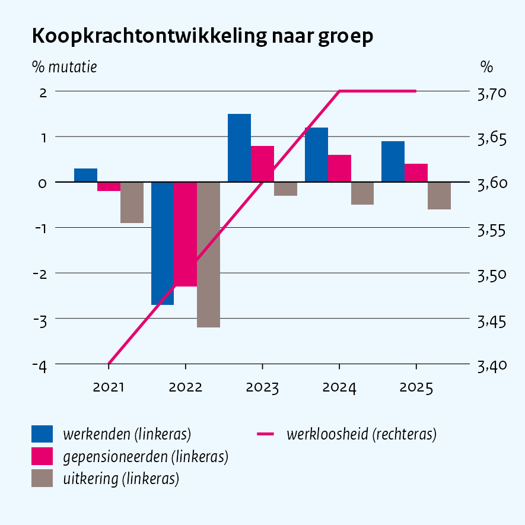

`werkloosheid` has no second axis, so it can be shown directly:

**Figure 2.** The line chart of the second figure in params.csv

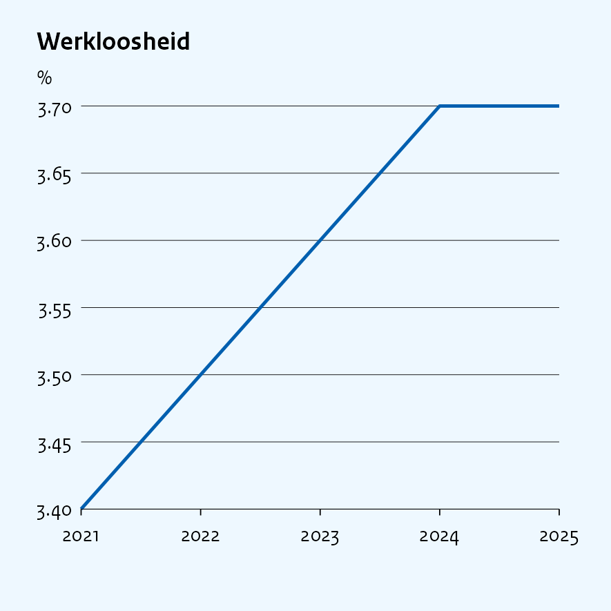

```r
figs$werkloosheid
```

# 5 Several datasets

The parameter `data` names the dataset of a figure, relative to the `data` folder next to `params.csv`. The extension `.csv` is optional, so `koopkracht` and `koopkracht.csv` are the same dataset.

| Parameter *data* | What happens |
| --- | --- |
| `koopkracht` | The figure uses `data/koopkracht.csv`. |
| `koopkracht;werkloosheid` | Two figures are made: one from `data/koopkracht.csv` and one from `data/werkloosheid.csv`. |
| blank | The figure uses `data/data.csv`. |
| column absent | The same as blank. |

The figures are named after their dataset. If several figures use the same dataset, the figure number is added to the name. The first figure column in `params.csv` is number 1. For example, `koopkracht_1.png` and `koopkracht_3.png`.

A named dataset that does not exist in the `data` folder is skipped with a warning. Nothing falls back to another dataset. The other datasets in the same list and the other rows are still created. With `data` set to `a;b;c` and no `b.csv`, you get figures for `a` and `c`, and a warning about `b.csv`.

## 5.1 A parameter file with one figure

A parameter file can describe a single figure or several figures. When describing only one figure, it has one column of values next to the parameter names. For example, the following describes a line chart. It can be saved in the same folder, so it finds the same `data` folder:

```r
params_one <- file.path(figure_dir, "params_one.csv")

writeLines(c(
  "plot_type,line",
  "title,Werkloosheid",
  "data,werkloosheid",
  "x,jaar",
  "y,werkloosheid",
  "ylab,%"
), params_one)

cat(readLines(params_one), sep = "\n")
```

```
#> plot_type,line
#> title,Werkloosheid
#> data,werkloosheid
#> x,jaar
#> y,werkloosheid
#> ylab,%
```

When the parameter file describes one figure, `figures_from_csv()` returns that figure directly rather than a named list. Use `simplify = FALSE` to always get a named list.

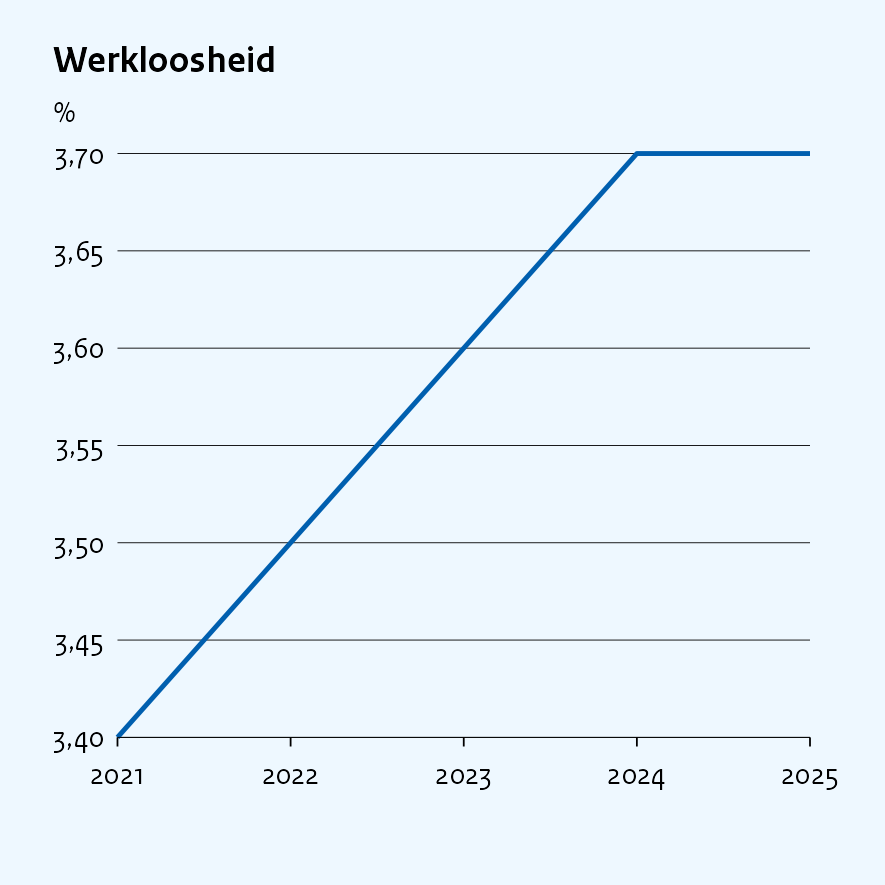

```r
fig_one <- figures_from_csv(params_one)
```

# 6 Settings for all figures

`general_settings` can be used to define settings that apply to all figures, such as `style`, `legend` or `page`. To do so, set the value in the `id` row to `general_settings`, as shown in the example below.

| id | general_settings | a | b | c |
| --- | --- | --- | --- | --- |
| plot_type |  | line | col | col |
| legend | filled-empty |  |  | none |
| page | full |  | half |  |
| dpi | 600 |  |  |  |

For each parameter, a value set for a specific figure overrides the value in `general_settings`. If the cell is empty, the value from `general_settings` is used instead.

In the example, figures a and b use the legend `filled-empty`, while figure c has no legend. Figure b is saved on a half page and the others on a full page.

Each parameter file can contain at most one `general_settings` column. However, including a `general_settings` column is optional.

# 7 Handling problems

A parameter can be left blank. In that case, the default value is used.

If a parameter is not valid for the selected `plot_type`, it is ignored and the default is used. This produces a warning.

If a figure cannot be created, for example because a column referenced by a parameter does not exist in the dataset, that figure is skipped. Other figures in the same parameter file are still created.

Each call to `figures_from_csv()` also writes a log file next to the parameter file. The log records parameter problems and figures that were created or skipped.

# Appendix A: Parameters

A parameter that refers to a variable (such as `x`, `y` or `fill`) takes a column name from the dataset. Every other parameter takes a value directly from the parameter file.

The available parameters depend on the `plot_type`. Table A1 lists every parameter once, with the plot types it belongs to, its default, an example and a short description. A default that differs per plot type is followed by the plot types it holds for.

**Table A1. All parameters**

| Parameter | Plot types | Default | Example | Description |
| --- | --- | --- | --- | --- |
| axis_text_size | col, line, box, dot, scatter, hist, boxplot_extended | 7 | 7 | The size of the axis text, in points. |
| bins | hist | none | 30 | The number of bins. |
| binwidth | hist | none | 5 | The width of one bin of the histogram. |
| border_colour | map | none | white | The colour of the region borders. |
| border_linewidth | map | 0.15 | 0.15 | The width of the region borders. |
| box_labels | box, boxplot_extended | none | TRUE | TRUE prints the values of the box. |
| box_style | box, boxplot_extended | modern: boxplot_extended ggcpb: rest | `ggcpb`, `james`, `modern` or `dot` | The look of the boxes. |
| cap_width | dot | 0.25 | 0.25 | The width of the end caps of the interval. |
| colour | line, dot, scatter | none | group | The column that gives lines or points their colour. |
| colour_index | all | none | `2;6`, `siren;cold_turkey`, `continuous` | Which house colours to use, by number or by name. The first is for the first category. The names are in `cpb_cols()`, for example `siren`. `continuous` gives a ramp from light to dark, for ordered cla… |
| cut | all | none | 0;20;40;Inf | Cuts the numbers of the colour column into classes. The values are the class limits. |
| cut_labels | all | number | `number`, `euro` or `pct` | How the class limits are written in the legend. |
| data | all | data | koopkracht | Excel workflow: CSV file in the data folder. Leave blank for data.csv. Write a;b for one figure per dataset. |
| dot_labels | box, boxplot_extended | none | p5:bottom 5%;p95:top 5% | Names for the dots of the dot style, as name:text pairs. |
| dpi | all | 300 | 800 | The sharpness of the saved image, in dots per inch. |
| facet | col, line, box, dot, scatter, hist, boxplot_extended | none | region | The column that splits the figure into panels. The number of panels equals the unique values of that column. |
| facet_ncol | col, line, box, dot, scatter, hist, boxplot_extended | none | 2 | The maximum number of panels next to each other per row. |
| facet_scales | col, line, box, dot, scatter, hist, boxplot_extended | fixed | `fixed`, `free`, `free_x` or `free_y` | Whether the panels share their axes (fixed) or each have their own (free). |
| fill | col, box, hist, donut, boxplot_extended | required | group | The column that splits the bars or areas into colours. |
| fill_colour | col, box, hist, boxplot_extended | none | #005faf | One colour for all bars or areas. It is used when `fill` is not set. |
| flush_legend | all | TRUE | TRUE | TRUE places the legend at the left edge of the figure. |
| forecast_label | col, line, scatter | raming | raming | The word shown in the forecast area. |
| forecast_x | col, line, scatter | none | 2025 | The x value where the forecast starts. Everything after it is shaded. |
| grid_colour | col, line, box, dot, scatter, hist, boxplot_extended | white: boxplot_extended black: rest | black | The colour of the grid lines. |
| grid_linewidth | col, line, box, dot, scatter, hist, boxplot_extended | 0.8: boxplot_extended 0.1: rest | 0.1 | The width of the grid lines. |
| group | col, box, dot, boxplot_extended | none | sector | The column that splits the data into groups. |
| group_gap | col, box, dot, boxplot_extended | 0.8: col 0.7: rest | 0.8 | The space between the groups, in bar widths. |
| height | all | none | 10 | The height of the saved figure in cm. Blank gives the standard height. |
| label | donut | none | name | The column with the text of each slice. |
| label_accuracy | box, donut, boxplot_extended | 1: donut 0.1: rest | 0.1 | The rounding of the printed percentages. 0.01 allows for two decimals. |

[output cut: 80 more lines]

All data in this document is made up. It is generated to show the figures and is not real data.